# Practical Machine Learning Course Project

Jakub Wiatrak

21 September 2018

## Introduction

The goal of this project is to predict the manner in which participants did a barbell lift excercise - to detect proper and improper methods of doing the excercise. The data has been gathered with devices, such as *Fitbit* or *Fuelband*.

The data for this project come from this source: http://groupware.les.inf.puc-rio.br/har.

## Loading required packages

```r
library(caret)
library(data.table)
library(rattle)
```

## Reading and preparing data

The training data is fairly large, so we will use *fread* function from *data.table* package. Next, we will clean the data, followed by splitting training set into training and validation set for cross-validation

```r
data <- fread("pml-training.csv")
data <- as.data.frame(data)

testing <- fread("pml-testing.csv")
testing <- as.data.frame(testing)

#Clean the data of variables with near zero variance
nzv <- nearZeroVar(data)
data.clean <- data[,-nzv]
testing <- testing[,-nzv]

#next, we will remove variables with NA values
NA_amount <- sapply(data.clean, function(x) {sum(is.na(x))/length(x)})
data.clean <- data.clean[,NA_amount < 0.2]
testing <- testing[,NA_amount < 0.2]

#finally, we will remove variables, that seem unreasonable to use in prediction,
#like timestamp and username
data.clean <- data.clean[,-(1:6)]
testing <- testing[,-(1:6)]

#next, we will split the training data into further training and test set
set.seed(2137)
inTrain <- createDataPartition(y=data.clean$classe,
                               p=0.7, list = F)

training <- data.clean[inTrain,]
validation <- data.clean[-inTrain,]
```

## Training Machine Learning Algorithms

We will train a few algorithms on the training data. Then we will perform a cross-validation, and choose the best model. We will use:

- decicion tree ( *rpart*)
- gradient boosting ( *gbm*)
- random forest ( *rf*)

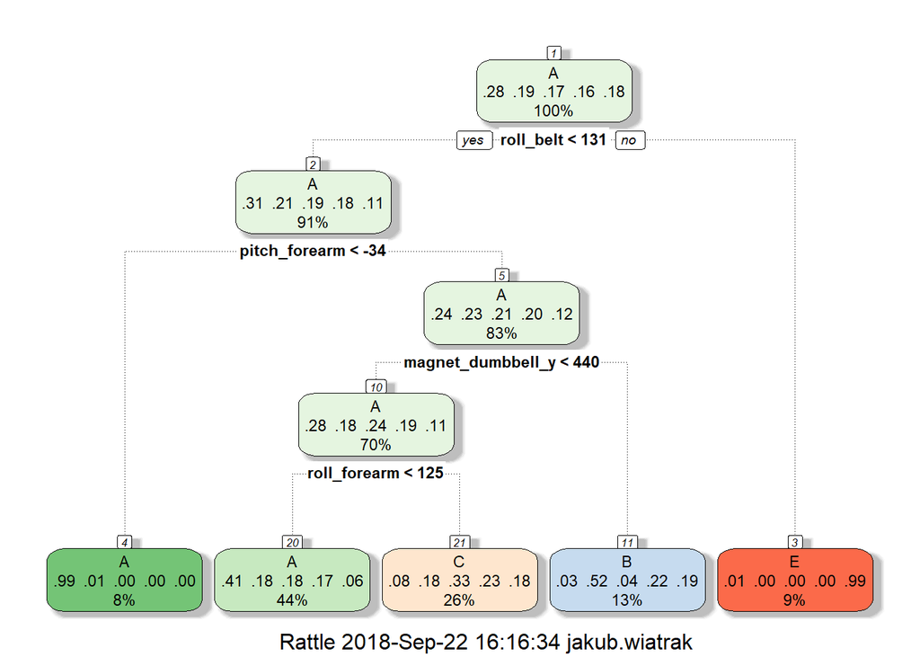

```r
#decision tree
fit_tree <- train(classe ~ ., data = training, method = "rpart")
fancyRpartPlot(fit_tree$finalModel)
```

```r
#gradient boosting
fit_gbm <- train(classe ~ ., data = training, method = "gbm")
```

```r
fit_gbm
```

```
## Stochastic Gradient Boosting
##
## 13737 samples
##    52 predictor
##     5 classes: 'A', 'B', 'C', 'D', 'E'
##
## No pre-processing
## Resampling: Bootstrapped (25 reps)
## Summary of sample sizes: 13737, 13737, 13737, 13737, 13737, 13737, ...
## Resampling results across tuning parameters:
##
##   interaction.depth  n.trees  Accuracy   Kappa
##   1                   50      0.7495273  0.6823972
##   1                  100      0.8191430  0.7710538
##   1                  150      0.8508741  0.8112632
##   2                   50      0.8542863  0.8153573
##   2                  100      0.9024533  0.8765248
##   2                  150      0.9267391  0.9072774
##   3                   50      0.8929240  0.8644181
##   3                  100      0.9359425  0.9189245
##   3                  150      0.9547163  0.9426980
##
## Tuning parameter 'shrinkage' was held constant at a value of 0.1
##
## Tuning parameter 'n.minobsinnode' was held constant at a value of 10
## Accuracy was used to select the optimal model using the largest value.
## The final values used for the model were n.trees = 150,
##  interaction.depth = 3, shrinkage = 0.1 and n.minobsinnode = 10.
```

```r
#random forest

#using parallel processing to shorten the time of fitting random forest algorithm
library(parallel)
library(doParallel)
cluster <- makeCluster(detectCores() - 1)
registerDoParallel(cluster)

fitControl <- trainControl(method = "cv",
                           number = 5,
                           allowParallel = TRUE)

fit_rf <- train(classe ~ ., data = training, method = "rf", trControl = fitControl)

stopCluster(cluster)
registerDoSEQ()
```

```r
fit_rf
```

```
## Random Forest
##
## 13737 samples
##    52 predictor
##     5 classes: 'A', 'B', 'C', 'D', 'E'
##
## No pre-processing
## Resampling: Cross-Validated (5 fold)
## Summary of sample sizes: 10990, 10987, 10990, 10990, 10991
## Resampling results across tuning parameters:
##
##   mtry  Accuracy   Kappa
##    2    0.9903181  0.9877516
##   27    0.9895905  0.9868307
##   52    0.9801267  0.9748582
##
## Accuracy was used to select the optimal model using the largest value.
## The final value used for the model was mtry = 2.
```

## Cross-validation

Now we will use the validation subset in order to correctly evaluate the accuracy of each model and choose the best one for prediction.

```r
#cross-validation of decision tree
pred_tree <- predict(fit_tree, validation)
confusionMatrix(pred_tree, as.factor(validation$classe))$overall[1]
```

```
##  Accuracy
## 0.4909091
```

```r
#cross-validation of gradient boosting
pred_gbm <- predict(fit_gbm, validation)
confusionMatrix(pred_gbm, as.factor(validation$classe))$overall[1]
```

```
##  Accuracy
## 0.9649958
```

```r
#cross-validation of random forest
pred_rf <- predict(fit_rf, validation)
confusionMatrix(pred_rf, as.factor(validation$classe))$overall[1]
```

```
##  Accuracy
## 0.9940527
```

Random forest is clearly the most accurate algorithm for predicting the *classe* variable.

## Prediction

Let’s use the best created algorithm - random forest - for predicting the final 20 observations.

```r
test_prediction <- predict(fit_rf, testing)
test_prediction
```

```
##  [1] B A B A A E D B A A B C B A E E A B B B
## Levels: A B C D E
```